# Document term frequency in R

Jae Yeon Kim

27 December, 2018

The following material is adapted from [Text Mining with R](https://proquest.safaribooksonline.com/9781491981641) (2017) by Julia Silge and David Robinson as well as [stm package manual](https://cran.r-project.org/web/packages/stm/vignettes/stmVignette.pdf) by Margaret E. Roberts, Brandon M. Stewart, and Dustin Tingley, and [stm tutorial](https://juliasilge.com/blog/evaluating-stm/) by again Julia Silge.

We touched on this concept briefly when we discussed tf-idf in the earlier session. It’s time for us now to dive into the analysis of word and document frequency more deeply. Then, we move onto the topic analysis.

# Setup

```r
rm(list=ls())

# load packages
require(tm) # for text mining
library(tidyverse) # for tidyverse
library(tidytext) # for tidy text analysis
library(quanteda) # for text analysis and examples
```

```r
library(wordcloud) # for wordcloud
library(stringr) # for string manipulation
library(gutenbergr) #  for text data
library(stm) # for topic modeling
library(drlib)

# load data
inaug <- tidy(data_corpus_inaugural)
```

# Document-term frequency

We have already seen this long tail distribution from Zipf’s law.

```r
# tokenize and count
inaug_words <- inaug %>%
  filter(Year > 1945) %>%
  unnest_tokens(word, text) %>%
  count(President, word, sort = TRUE)

# total nunber of tokens
inaug_total_words <- inaug_words %>%
  group_by(President) %>%
  summarize(total = sum(n))

# merge
inaug_words <- left_join(inaug_words, inaug_total_words)
```

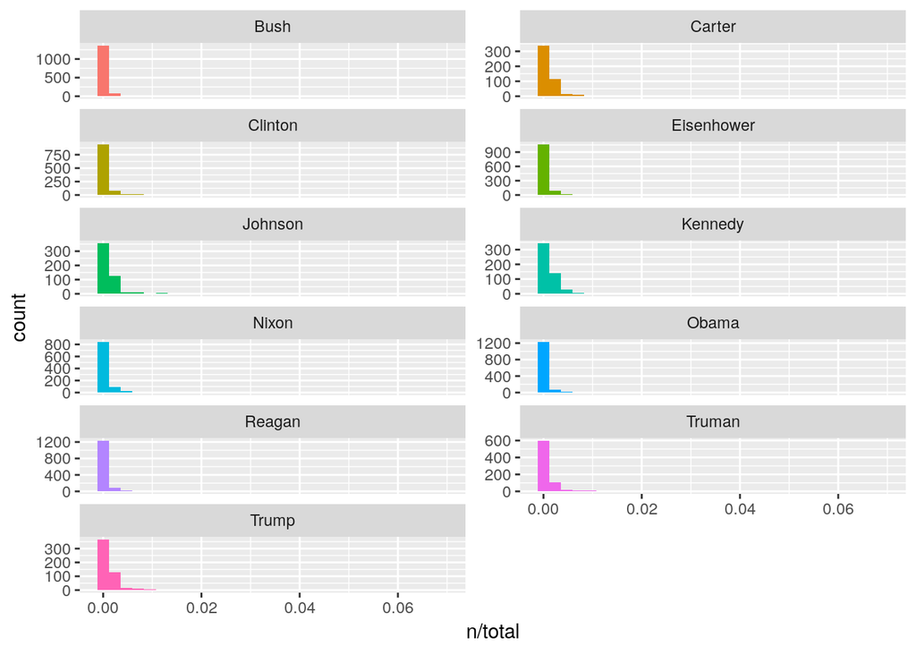

```r
# plot
ggplot(inaug_words, aes(x = n/total, fill = President)) +
  geom_histogram(show.legend = FALSE) +
  facet_wrap(~President, ncol = 2, scales = "free_y")
```

# Topic modeling

## Turn text into dfm

stm package has its own preprocessing tool called textProcessor.

```r
inaug_dfm <- textProcessor(documents = inaug$text, metadata = inaug,
                            removestopwords = TRUE,
                            verbose = TRUE)
```

```
## Building corpus...
## Converting to Lower Case...
## Removing punctuation...
## Removing stopwords...
## Removing numbers...
## Stemming...
## Creating Output...
```

## Find the right number of topics

- K is the number of topics.
- Let’s try K = 5, 10, 15 this time.
- But also mind that finding K is computationally expensive. If your machine is too slow, then consider using parallel processing.

```r
# using searchK function
storage <- searchK(inaug_dfm$documents, inaug_dfm$vocab, K = c(5, 10, 15),
        prevalence =~ Year + President, data = inaug_dfm$meta)
```

[output not shown]

[output cut: 514 more lines]

[output not shown]